# Final Project

Arthur Moore

August 13, 2020

## Introduction

The aim of the following studies was to see if there was sufficient correlation between Respiratory Ailments and COVID-19 deaths and cases.

## Section 1: Deaths with Underlying Conditions

This section deals with death from COVID-19 where a underlying condition was also observed. The figures were derived from the CDC Dataset on underlying conditions. And the CDC dataset of Provisional Death Counts.

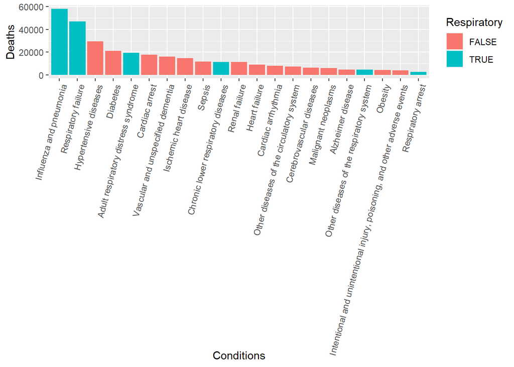

**Figure 1**: Deaths with Underlying Conditions

Table 2: Provisional Death Anova

|  | Df | Sum Sq | Mean Sq | F value | Pr(>F) |
| --- | --- | --- | --- | --- | --- |
| Respiratory | 1 | 654518519 | 654518519 | 3.659 | 0.071 |
| Residuals | 19 | 3399136143 | 178901902 | NA | NA |

This figure shows key factors causing the most deaths with COVID 19 in a single category are respiratory based. Influenza/ pneumonia take the top spot with Respiratory failure coming in second. The ANOVA analysis did not show significant correlation between respiratory ailments as the p value was above 0.05 Below is a table so you can also analyze the hard numbers.

| Condition | Number of COVID-19 Deaths | Respiratory |
| --- | --- | --- |
| Influenza and pneumonia | 57970 | TRUE |
| Respiratory failure | 46921 | TRUE |
| Hypertensive diseases | 29425 | FALSE |
| Diabetes | 21185 | FALSE |
| Adult respiratory distress syndrome | 19435 | TRUE |
| Cardiac arrest | 17867 | FALSE |
| Vascular and unspecified dementia | 16075 | FALSE |
| Ischemic heart disease | 14965 | FALSE |
| Sepsis | 11689 | FALSE |
| Chronic lower respiratory diseases | 11510 | TRUE |
| Renal failure | 11484 | FALSE |
| Heart failure | 8996 | FALSE |
| Cardiac arrhythmia | 8222 | FALSE |
| Other diseases of the circulatory system | 7357 | FALSE |
| Cerebrovascular diseases | 6525 | FALSE |
| Malignant neoplasms | 6282 | FALSE |
| Alzheimer disease | 4731 | FALSE |
| Other diseases of the respiratory system | 4713 | TRUE |
| Obesity | 4342 | FALSE |
| Intentional and unintentional injury, poisoning, and other adverse events | 4127 | FALSE |
| Respiratory arrest | 2908 | TRUE |

| Start week | All COVID-19 Deaths | Deaths with Pneumonia and COVID-19 | Percent of COVID Deaths involving Pneumonia |
| --- | --- | --- | --- |
| 2/29/2020 | 5 | 3 | 60.00 |
| 3/7/2020 | 25 | 14 | 56.00 |
| 3/14/2020 | 49 | 25 | 51.02 |
| 3/21/2020 | 487 | 224 | 46.00 |
| 3/28/2020 | 2659 | 1220 | 45.88 |
| 4/4/2020 | 7932 | 3813 | 48.07 |
| 4/11/2020 | 11864 | 5281 | 44.51 |
| 4/18/2020 | 9333 | 3874 | 41.51 |
| 4/25/2020 | 2167 | 847 | 39.09 |

This table shows a high correlation between the amount of COVID-19 deaths per week and that patient also having pneumonia. But this data is only over the course of around 2 months. I could make more definite analysis on it if a few more months were present.

## Section 2: Hospital Visits vs. Underlying Conditions

In this section we will explore if there is a correlation between COVID-19 hospitalizations and the underlying conditions that accompanied them. The data was derived from the CDC Covid-Net datasets on medical conditions for adults and for children

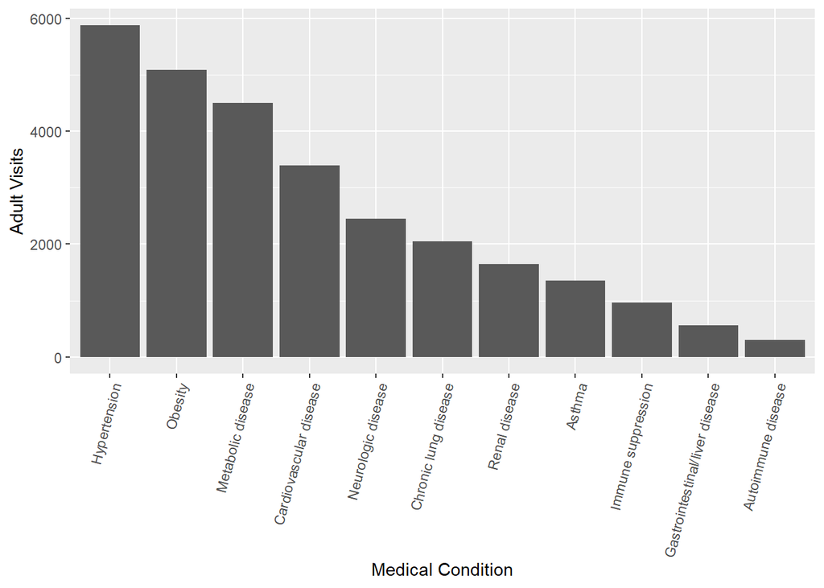

**Figure 2**: Hospital Visits for Adults with accompanying conditions.

In this case we see in the COVID Center data that among hospitalizations in the US that hypertension was the largest underlying condition observed for adults. Respiratory afflictions like Asthma did not rank very highly. Below is a table of these results

| MEDICAL CONDITION | Adult Visits |
| --- | --- |
| Hypertension | 5874 |
| Obesity | 5080 |
| Metabolic disease | 4500 |
| Cardiovascular disease | 3395 |
| Neurologic disease | 2451 |
| Chronic lung disease | 2046 |
| Renal disease | 1648 |
| Asthma | 1356 |
| Immune suppression | 959 |
| Gastrointestinal/liver disease | 562 |
| Autoimmune disease | 298 |

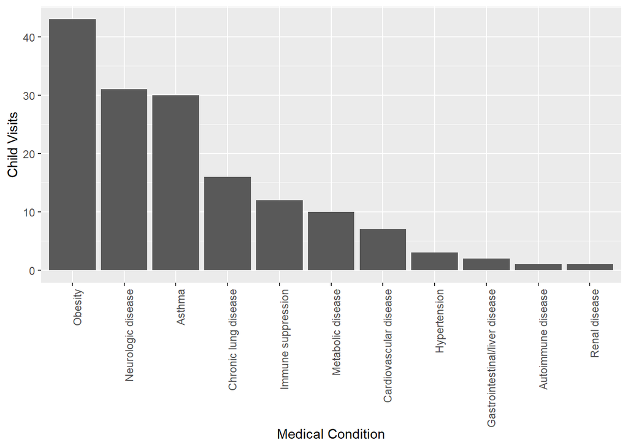

**Figure 3**: COVID-19 Children Hospitilaztions with accompanying conditions.

| MEDICAL CONDITION | Child Visits |
| --- | --- |
| Obesity | 43 |
| Neurologic disease | 31 |
| Asthma | 30 |
| Chronic lung disease | 16 |
| Immune suppression | 12 |
| Metabolic disease | 10 |
| Cardiovascular disease | 7 |
| Hypertension | 3 |
| Gastrointestinal/liver disease | 2 |
| Autoimmune disease | 1 |
| Renal disease | 1 |

The most likely underlying cause when it came to children was having was obesity with Asthma coming in third. In both the cases of children and adults a respiratory ailment was not the number underlying condition to go with hospitalization.

## Conclusion

While incidents of respiratory ailments were high among deaths I did not find enough data to significantly reject my null hypothesis. My data does show that a high percentage of COVID-19 deaths are comorbid with pneumonia. In the case of hospitalizations the most like underlying conditions were obesity and hypertension. For further analysis I would need to gather more data from more countries as the bulk of my data came from America. Americans may skew some of the numbers as obesity and hypertension are large scale American issues.